# Python code to generate figures from Lecture 1 and 2

```python
# General purpose packages (data handling, pretty plotting, ...)
import numpy as np
import pandas as pd
import matplotlib.pyplot as plt
import seaborn as sns
from scipy.stats import multivariate_normal
from scipy.special import expit  # Logistic function
from scipy.stats import norm

# Color-blind friendly palette
cbPalette = [
    "#999999", "#E69F00", "#56B4E9", "#009E73",
    "#F0E442", "#0072B2", "#D55E00", "#CC79A7"
]

# Set default plot style
plt.style.use('seaborn-v0_8-darkgrid')
sns.set_palette(cbPalette)
```

## Linear regression: our old friend.

The 5 basic assumptions for linear regression via OLS (ordinary least squares)?

1. Model adequacy
2. Uncorrelated errors
3. Mean 0 errors
4. Constant error variance
5. No outliers

Why do you need this and what happens if you violate the assumptions?

1. If the model doesn't fit you get local biases and systematic prediction errors. Try a different model, model family (for non-additive errors for example), data tranformations, additional feautures.
2. If the errors aren't uncorrelated you should use time series or mixed effects models. If you ignore this violation you overestimate the degrees of freedom of the data and noise which leads to misleading p-values/uncertainty quantification and sometimes to worse predictions. Sometimes you can decorrelated the data (detrend etc).
3. This is an example of a model inadequacy - if the errors are skewed you are perhaps missing subpopulations in the data, perhaps you need to transform the data, or you need to use a different error distribution and loss.
4. This is about data efficiency. If some data are of worse quality they should not contribute as much as those of high quality - it leads to less efficient estimates (more variation in estimates and predictions than necessary). Solution: data transformations to surpress the variance (e.g. log or sqrt) or weighted least squares.
5. If there are outliers in the data, mse loss is a bad idea - this can lead to outliers driving the estimation/model and thus the model is a poor fit for everyone! Solution: other loss functions like M-estimation etc/robust statistics or dropping outliers - the latter is a tricky business. Is it OK to drop 5 percent of observations? 25? When does this stop being outliers and start being model inadequacy?

```python
# Linear regression example
np.random.seed(4224)
n = 20  # Total number of observations

# Design matrix: intercept + x values
x = np.linspace(0.5, 2, n)
X_train = np.column_stack([np.ones(n), x])

beta_true = np.array([1, 0.7])  # Coefficients
sigma_true = 0.25  # Residual error variance
y_train = X_train @ beta_true + sigma_true * np.random.randn(n)

# Create DataFrame for easier handling
data_train = pd.DataFrame({'x': x, 'y': y_train})
```

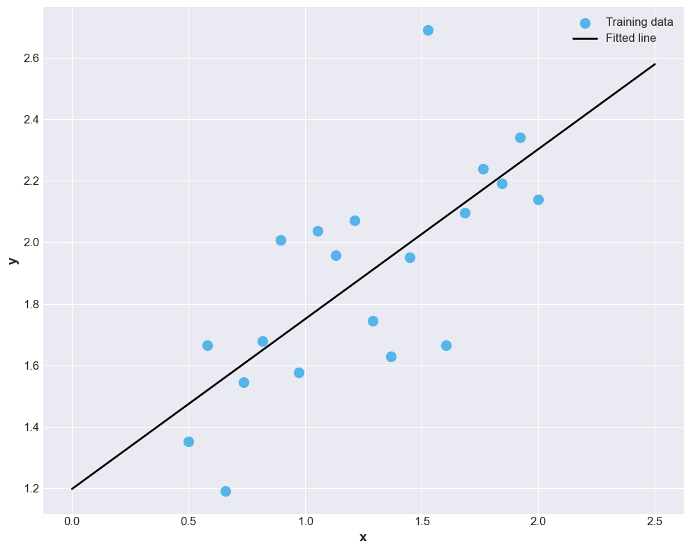

```python
# Fit linear model
from numpy.polynomial import polynomial as P

# Simple OLS: solve X^T X beta = X^T y
beta = np.linalg.lstsq(X_train, y_train, rcond=None)[0]

# Data for plotting the line
x_pred = np.array([0, 2.5])
X_pred = np.column_stack([np.ones(len(x_pred)), x_pred])
y_pred = X_pred @ beta

data_pred = pd.DataFrame({'x': x_pred, 'y': y_pred})

# Plot results
plt.figure(figsize=(10, 8))
plt.scatter(data_train['x'], data_train['y'], s=100, color=cbPalette[2], label='Training data')
plt.plot(data_pred['x'], data_pred['y'], color='black', linewidth=2, label='Fitted line')
plt.xlabel('x', fontsize=14, fontweight='bold')
plt.ylabel('y', fontsize=14, fontweight='bold')
plt.xticks(fontsize=12)
plt.yticks(fontsize=12)
plt.legend(fontsize=12)
plt.tight_layout()
plt.show()
```

In class we showed that the conditional expectation in slices of x is an approximation of the best predictor: the actual population conditional expectation $E[y|x]$.

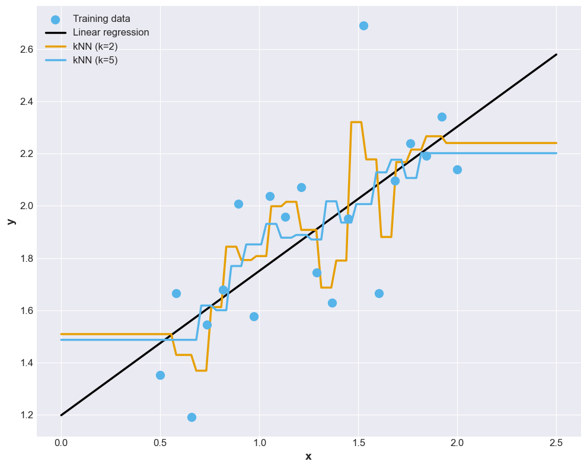

```python
# k-neighbor regression example
ks = [2, 5]
x_pred = np.linspace(0, 2.5, 100)

# Compute kNN predictions for each point in x_pred
y_preds = []
for k in ks:
    y_pred_k = []
    for x in x_pred:
        # Find distances to all training points
        distances = np.abs(data_train['x'].values - x)
        # Get indices of k nearest neighbors
        nearest_idx = np.argsort(distances)[:k]
        # Average the y values of k nearest neighbors
        y_pred_k.append(y_train[nearest_idx].mean())
    y_preds.append(np.array(y_pred_k))

# Prepare data for plotting
data_pred_nb = pd.DataFrame({
    'x': np.tile(x_pred, len(ks)),
    'y': np.concatenate(y_preds),
    'k': np.repeat(ks, len(x_pred))  # Store as integers, not strings
})

# Plot
plt.figure(figsize=(10, 8))
plt.scatter(data_train['x'], data_train['y'], s=100, color=cbPalette[2], label='Training data', zorder=3)
plt.plot(data_pred['x'], data_pred['y'], color='black', linewidth=2.5, label='Linear regression')

# Plot kNN predictions
for i, k in enumerate(ks):
    data_k = data_pred_nb[data_pred_nb['k'] == k]
    plt.plot(data_k['x'], data_k['y'], linewidth=2.5, color=cbPalette[i+1], label=f'kNN (k={k})')

plt.xlabel('x', fontsize=14, fontweight='bold')
plt.ylabel('y', fontsize=14, fontweight='bold')
plt.xticks(fontsize=12)
plt.yticks(fontsize=12)
plt.legend(fontsize=12)
plt.tight_layout()
plt.show()
```

Try some other k at home...

## Classification example

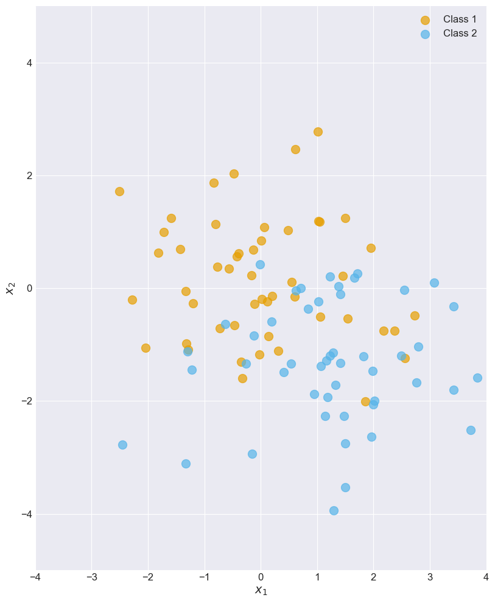

```python
# Classification example: simulate data for two classes
np.random.seed(43)
n = 50  # Same number of elements per class

# Means of the classes
mu = np.array([[0, 0], [1.25, -1.25]])
Sigma = np.diag([1.5, 1.5])  # Covariance matrix

# Generate variables
X_train = np.vstack([
    multivariate_normal.rvs(mean=mu[0], cov=Sigma, size=n),
    multivariate_normal.rvs(mean=mu[1], cov=Sigma, size=n)
])

y_train = np.array([1]*n + [2]*n)

# Prepare data for plotting
data_train = pd.DataFrame({
    'class': y_train,
    'x1': X_train[:, 0],
    'x2': X_train[:, 1]
})

# Plot
plt.figure(figsize=(10, 10))
for cls in [1, 2]:
    mask = data_train['class'] == cls
    plt.scatter(data_train[mask]['x1'], data_train[mask]['x2'],
               s=100, label=f'Class {cls}', color=cbPalette[cls], alpha=0.7)

plt.xlabel(r'$x_1$', fontsize=14, fontweight='bold')
plt.ylabel(r'$x_2$', fontsize=14, fontweight='bold')
plt.xlim(-4, 4)
plt.ylim(-5, 5)
plt.xticks(fontsize=12)
plt.yticks(fontsize=12)
plt.legend(fontsize=12)
plt.gca().set_aspect('equal')
plt.tight_layout()
plt.show()
```

In class we discussed what the loss and corresponding best predictors are for classification. We showed that the conditional mean now corresponds to conditional (or local) probabilities for classes.

This can be approximated by local majority voting decisions (k nearest neighbors).

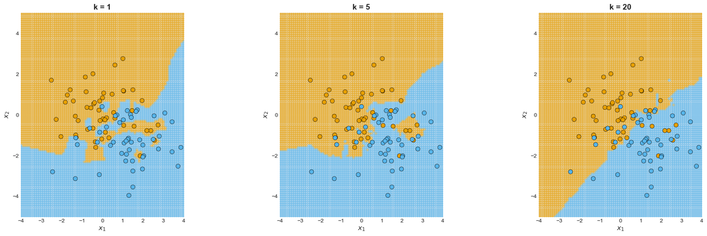

```python
# kNN classification example
from sklearn.neighbors import KNeighborsClassifier

# Create a grid where we predict the class
h = 0.1  # Step-width
x1_arr = np.arange(-4, 4.1, h)
x2_arr = np.arange(-5, 5.1, h)
x1_grid, x2_grid = np.meshgrid(x1_arr, x2_arr)
X_grid = np.column_stack([x1_grid.ravel(), x2_grid.ravel()])

# Use kNN with different k values
ks = [1, 5, 20]
predictions = []

for k in ks:
    clf = KNeighborsClassifier(n_neighbors=k)
    clf.fit(X_train, y_train)
    y_pred = clf.predict(X_grid)
    predictions.append(y_pred)

# Prepare data for plotting
data_pred = pd.DataFrame({
    'class': np.concatenate(predictions),
    'x1': np.tile(X_grid[:, 0], len(ks)),
    'x2': np.tile(X_grid[:, 1], len(ks)),
    'k': np.repeat([f'k = {k}' for k in ks], len(X_grid))
})

# Plot
fig, axes = plt.subplots(1, 3, figsize=(20, 6))

for idx, (ax, k) in enumerate(zip(axes, ks)):
    data_k = data_pred[data_pred['k'] == f'k = {k}']

    # Plot decision boundary
    for cls in [1, 2]:
        mask = data_k['class'] == cls
        ax.scatter(data_k[mask]['x1'], data_k[mask]['x2'],
                  s=20, color=cbPalette[cls], alpha=0.4)

    # Plot training data
    for cls in [1, 2]:
        mask = data_train['class'] == cls
        ax.scatter(data_train[mask]['x1'], data_train[mask]['x2'],
                  s=60, color=cbPalette[cls], edgecolors='black', linewidth=0.5)

    ax.set_xlim(-4, 4)
    ax.set_ylim(-5, 5)
    ax.set_xlabel(r'$x_1$', fontsize=12, fontweight='bold')
    ax.set_ylabel(r'$x_2$', fontsize=12, fontweight='bold')
    ax.set_title(f'k = {k}', fontsize=14, fontweight='bold')
    ax.set_aspect('equal')
    ax.grid(True, alpha=0.3)

plt.tight_layout()
plt.show()
```

Notice how small k leads to flexible decision boundaries between the classes whereas large k is more smooth or restrictive, borrowing more information across observations in the training sample.

Logistic regression is a parametric classifier that generalizes linear regression to a binary outcome setting. Here, we assume that the data comes from independent Bernouilli draws but that the class probability is observation specific through the features.

Now, a 0-1 regression is a pretty good approach for binary classification but the interpretation is odd since the resulting class probability predictions can be any value on the real line. We fix this by using either the logit or probit link functions to map the real line to the 0-1 interval.

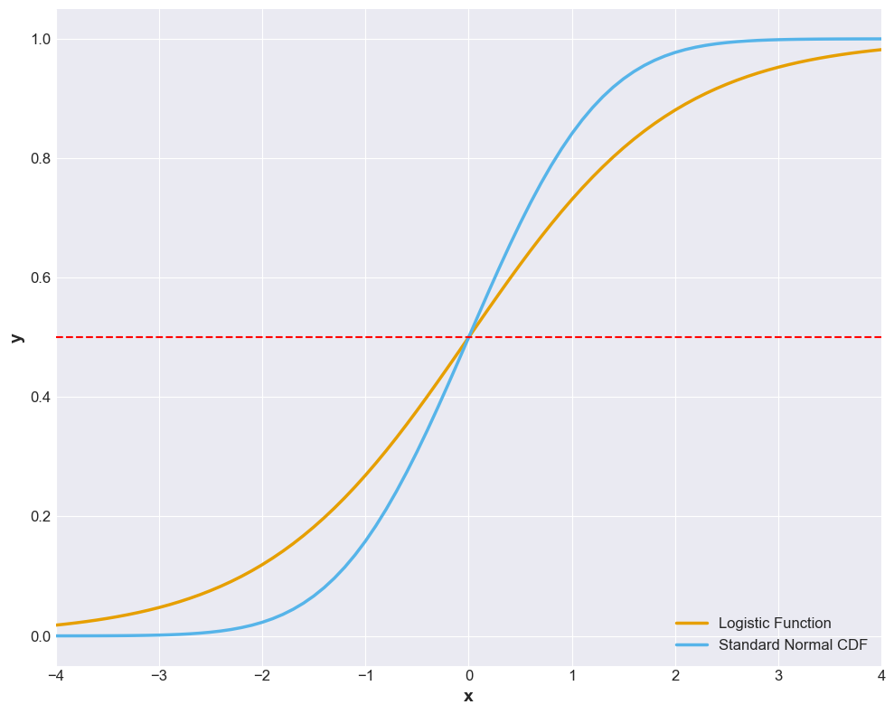

```python
# Logistic function and normal CDF comparison
xs = np.arange(-4, 4.1, 0.1)

ys_logistic = expit(xs)  # Logistic function
ys_normal_cdf = norm.cdf(xs)  # Standard normal CDF

# Plot
plt.figure(figsize=(10, 8))
plt.plot(xs, ys_logistic, linewidth=2.5, color=cbPalette[1], label='Logistic Function')
plt.plot(xs, ys_normal_cdf, linewidth=2.5, color=cbPalette[2], label='Standard Normal CDF')
plt.axhline(y=0.5, color='red', linestyle='--', linewidth=1.5)

plt.xlabel('x', fontsize=14, fontweight='bold')
plt.ylabel('y', fontsize=14, fontweight='bold')
plt.xticks(fontsize=12)
plt.yticks(fontsize=12)
plt.legend(fontsize=12, loc='lower right')
plt.xlim(-4, 4)
plt.tight_layout()
plt.show()
```

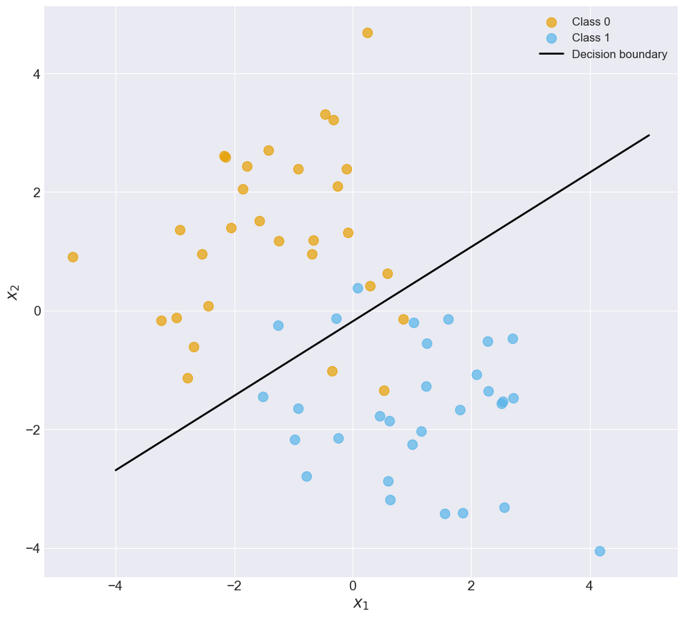

```python
# Example logistic regression
from sklearn.linear_model import LogisticRegression

np.random.seed(7334482)

# Simulate two nicely separated datasets
n = 30
mu = np.array([[-1.5, 1.5], [1.5, -1.5]])
Sigma = np.diag([1.5, 1.5])

# Generate variables
X_train = np.vstack([
    multivariate_normal.rvs(mean=mu[0], cov=Sigma, size=n),
    multivariate_normal.rvs(mean=mu[1], cov=Sigma, size=n)
])

y_train = np.array([0]*n + [1]*n)

data_train = pd.DataFrame({
    'x1': X_train[:, 0],
    'x2': X_train[:, 1],
    'class': y_train
})

# Fit logistic regression
clf = LogisticRegression()
clf.fit(X_train, y_train)

# Decision boundary: -beta0 - beta1*x1 = beta2*x2  =>  x2 = (-beta0 - beta1*x1) / beta2
beta = np.concatenate([[clf.intercept_[0]], clf.coef_[0]])

x1_pred = np.array([-4, 5])
x2_pred = (-beta[0] - beta[1] * x1_pred) / beta[2]

# Plot
plt.figure(figsize=(10, 10))
for cls in [0, 1]:
    mask = data_train['class'] == cls
    plt.scatter(data_train[mask]['x1'], data_train[mask]['x2'],
               s=100, label=f'Class {cls}', color=cbPalette[cls+1], alpha=0.7)

plt.plot(x1_pred, x2_pred, color='black', linewidth=2, label='Decision boundary')

plt.xlabel(r'$x_1$', fontsize=16, fontweight='bold')
plt.ylabel(r'$x_2$', fontsize=16, fontweight='bold')
plt.xticks(fontsize=14)
plt.yticks(fontsize=14)
plt.legend(fontsize=12)
plt.gca().set_aspect('equal')
plt.tight_layout()
plt.show()
```

The decision boundary is the points in x-space where the logit-function hits 0, or equivalently the estimated class probabilties cross 0.5.

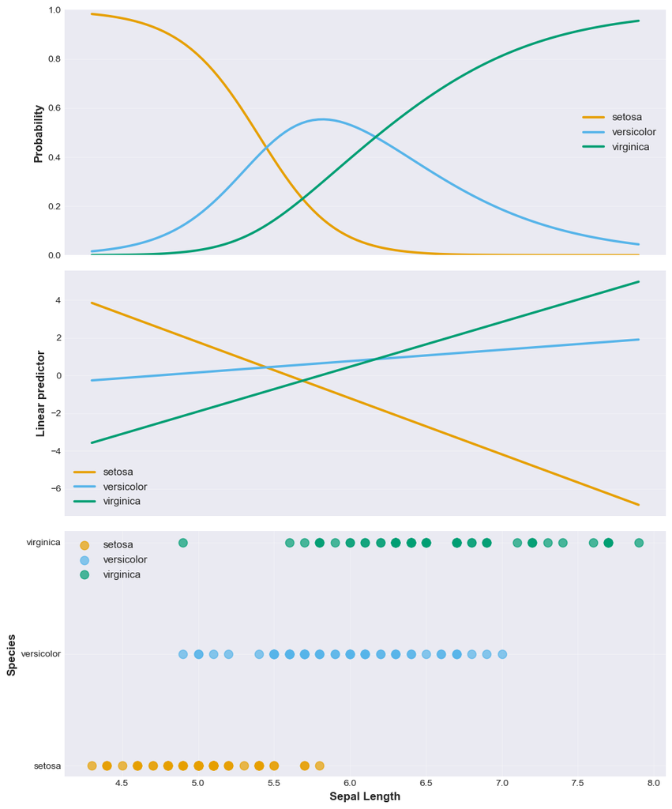

```python
# Multi-class logistic regression example using Iris dataset
from sklearn.datasets import load_iris
from sklearn.linear_model import LogisticRegression

# Load Iris dataset
iris = load_iris()
X = iris.data[:, :1]  # Use only first feature (Sepal Length)
y = iris.target
species = iris.target_names

# Fit multinomial logistic model (default for multi-class problems)
clf = LogisticRegression(max_iter=1000)
clf.fit(X, y)

# Prepare prediction data
n_pred = 100
X_pred = np.linspace(4.2, 8.1, n_pred).reshape(-1, 1)

# Get probabilities
y_pred_proba = clf.predict_proba(X_pred)

# Get linear predictors (for reference)
y_pred_lin = clf.decision_function(X_pred)

# Create DataFrames for plotting
data_pred_proba = pd.DataFrame({
    'x': np.repeat(X_pred.ravel(), 3),
    'y': y_pred_proba.ravel(),
    'Species': np.tile(species, n_pred)
})

data_pred_lin = pd.DataFrame({
    'x': np.repeat(X_pred.ravel(), 3),
    'y': y_pred_lin.ravel(),
    'Species': np.tile(species, n_pred)
})

data_train_iris = pd.DataFrame({
    'x': X.ravel(),
    'y': y,
    'Species': [species[i] for i in y]
})

# Create subplots
fig, axes = plt.subplots(3, 1, figsize=(10, 12))

# Plot 1: Probabilities
ax = axes[0]
for i, sp in enumerate(species):
    data_sp = data_pred_proba[data_pred_proba['Species'] == sp]
    ax.plot(data_sp['x'], data_sp['y'], linewidth=2.5, color=cbPalette[i+1], label=sp)
ax.set_ylabel('Probability', fontsize=12, fontweight='bold')
ax.set_xticks([])
ax.set_ylim(0, 1)
ax.legend(fontsize=11)
ax.grid(True, alpha=0.3)

# Plot 2: Linear predictors
ax = axes[1]
for i, sp in enumerate(species):
    data_sp = data_pred_lin[data_pred_lin['Species'] == sp]
    ax.plot(data_sp['x'], data_sp['y'], linewidth=2.5, color=cbPalette[i+1], label=sp)
ax.set_ylabel('Linear predictor', fontsize=12, fontweight='bold')
ax.set_xticks([])
ax.legend(fontsize=11)
ax.grid(True, alpha=0.3)

# Plot 3: Training data
ax = axes[2]
for i, sp in enumerate(species):
    mask = data_train_iris['Species'] == sp
    ax.scatter(data_train_iris[mask]['x'], data_train_iris[mask]['y'],
              s=80, color=cbPalette[i+1], label=sp, alpha=0.7)
ax.set_xlabel('Sepal Length', fontsize=12, fontweight='bold')
ax.set_ylabel('Species', fontsize=12, fontweight='bold')
ax.set_yticks([0, 1, 2])
ax.set_yticklabels(species)
ax.legend(fontsize=11)
ax.grid(True, alpha=0.3)

plt.tight_layout()
plt.show()
```

Nearest centroid classifiers are very popular due to their simplicity. They are cheap in terms of parameters BUT they do assume a lot about the data without stating so - the class shapes and variabilities are ignored in the classification rule so that implies that you assume that the shapes are the same and the variances in all dimensions as well....

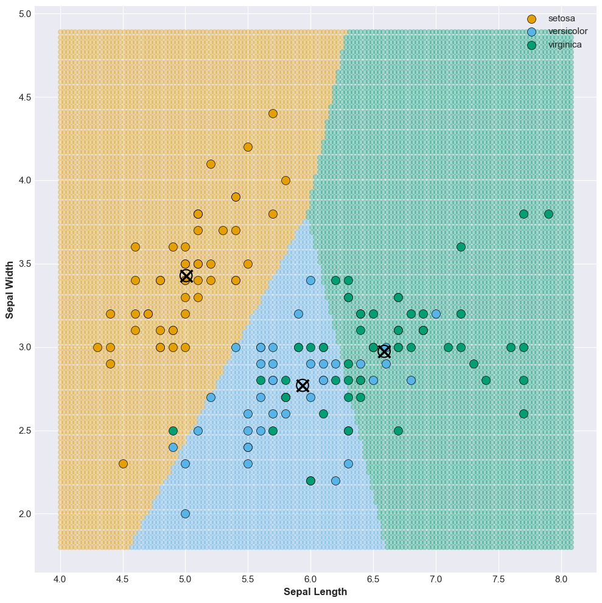

```python
# Nearest centroid classifier example
from sklearn.datasets import load_iris

# Load iris data
iris = load_iris()
X = iris.data[:, [0, 1]]  # Use Sepal Length and Sepal Width
y = iris.target
species = iris.target_names

data_train = pd.DataFrame({
    'class': [species[i] for i in y],
    'x1': X[:, 0],
    'x2': X[:, 1]
})

# Calculate centroids per class
data_centroid = data_train.groupby('class')[['x1', 'x2']].mean().reset_index()
centroids = data_centroid[['x1', 'x2']].values

# Create prediction grid
h = 0.03
x1s = np.arange(4, 8.1, h)
x2s = np.arange(1.8, 4.9, h)
x1_grid, x2_grid = np.meshgrid(x1s, x2s)
X_grid = np.column_stack([x1_grid.ravel(), x2_grid.ravel()])

# Classify with nearest centroid method
# Compute distances from each point to each centroid
distances = np.zeros((X_grid.shape[0], len(centroids)))
for i, centroid in enumerate(centroids):
    distances[:, i] = np.linalg.norm(X_grid - centroid, axis=1)

y_pred = np.argmin(distances, axis=1)

data_pred = pd.DataFrame({
    'x1': X_grid[:, 0],
    'x2': X_grid[:, 1],
    'class': np.array(species)[y_pred]
})

# Plot
plt.figure(figsize=(10, 10))

# Plot decision boundary
for cls in species:
    mask = data_pred['class'] == cls
    idx = np.where(iris.target_names == cls)[0][0]
    plt.scatter(data_pred[mask]['x1'], data_pred[mask]['x2'],
               s=30, color=cbPalette[idx+1], alpha=0.3)

# Plot training data
for cls in species:
    mask = data_train['class'] == cls
    idx = np.where(iris.target_names == cls)[0][0]
    plt.scatter(data_train[mask]['x1'], data_train[mask]['x2'],
               s=100, color=cbPalette[idx+1], edgecolors='black', linewidth=0.5, label=cls)

# Plot centroids
plt.scatter(data_centroid['x1'], data_centroid['x2'],
           s=200, marker='x', color='black', linewidth=2.5)
plt.scatter(data_centroid['x1'], data_centroid['x2'],
           s=200, marker='o', facecolors='none', edgecolors='black', linewidth=1.5)

plt.xlabel('Sepal Length', fontsize=12, fontweight='bold')
plt.ylabel('Sepal Width', fontsize=12, fontweight='bold')
plt.xticks(fontsize=11)
plt.yticks(fontsize=11)
plt.legend(fontsize=11, loc='upper right')
plt.tight_layout()
plt.show()
```

If we want to be less stringent in our assumptions we can assume that features can be correlated and have different variances, i.e., that the classes have non-spherical shapes in x-space. This is what discriminant analysis does.

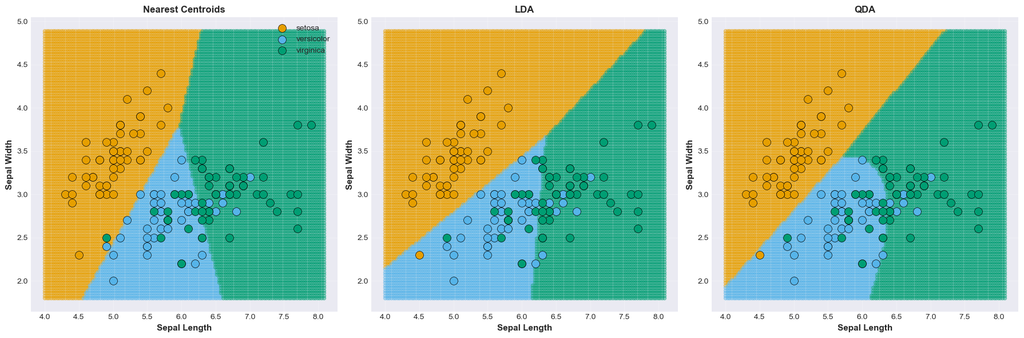

```python
# LDA and QDA comparison
from sklearn.discriminant_analysis import LinearDiscriminantAnalysis, QuadraticDiscriminantAnalysis
from sklearn.datasets import load_iris

# Load iris data
iris = load_iris()
X = iris.data[:, [0, 1]]  # Use Sepal Length and Sepal Width
y = iris.target
species = iris.target_names

data_train = pd.DataFrame({
    'class': [species[i] for i in y],
    'x1': X[:, 0],
    'x2': X[:, 1]
})

# Create prediction grid
h = 0.03
x1s = np.arange(4, 8.1, h)
x2s = np.arange(1.8, 4.9, h)
x1_grid, x2_grid = np.meshgrid(x1s, x2s)
X_grid = np.column_stack([x1_grid.ravel(), x2_grid.ravel()])

# Fit LDA and QDA
lda = LinearDiscriminantAnalysis()
qda = QuadraticDiscriminantAnalysis()
lda.fit(X, y)
qda.fit(X, y)

# Predictions
y_pred_lda = lda.predict(X_grid)
y_pred_qda = qda.predict(X_grid)

# Also compute nearest centroid
data_centroid = data_train.groupby('class')[['x1', 'x2']].mean().reset_index()
centroids = data_centroid[['x1', 'x2']].values

# Compute distances from each point to each centroid
distances = np.zeros((X_grid.shape[0], len(centroids)))
for i, centroid in enumerate(centroids):
    distances[:, i] = np.linalg.norm(X_grid - centroid, axis=1)

y_pred_centroid = np.argmin(distances, axis=1)

data_pred_all = pd.DataFrame({
    'x1': X_grid[:, 0],
    'x2': X_grid[:, 1],
    'class_centroid': np.array(species)[y_pred_centroid],
    'class_lda': np.array(species)[y_pred_lda],
    'class_qda': np.array(species)[y_pred_qda]
})

# Create subplots
fig, axes = plt.subplots(1, 3, figsize=(18, 6))
methods = ['Nearest Centroids', 'LDA', 'QDA']
class_cols = ['class_centroid', 'class_lda', 'class_qda']

for ax, method, class_col in zip(axes, methods, class_cols):
    # Plot decision boundary
    for cls in species:
        mask = data_pred_all[class_col] == cls
        idx = np.where(iris.target_names == cls)[0][0]
        ax.scatter(data_pred_all[mask]['x1'], data_pred_all[mask]['x2'],
                  s=20, color=cbPalette[idx+1], alpha=0.4)

    # Plot training data
    for cls in species:
        mask = data_train['class'] == cls
        idx = np.where(iris.target_names == cls)[0][0]
        ax.scatter(data_train[mask]['x1'], data_train[mask]['x2'],
                  s=100, color=cbPalette[idx+1], edgecolors='black', linewidth=0.5, label=cls)

    ax.set_xlabel('Sepal Length', fontsize=11, fontweight='bold')
    ax.set_ylabel('Sepal Width', fontsize=11, fontweight='bold')
    ax.set_title(method, fontsize=12, fontweight='bold')
    ax.grid(True, alpha=0.3)
    if ax == axes[0]:
        ax.legend(fontsize=10)

plt.tight_layout()
plt.show()
```

Let's have a look at another data set - the Wisconsin breast cancer data set.

```python
# Load breast cancer data
from sklearn.datasets import load_breast_cancer

# Load the dataset
bc = load_breast_cancer()
X = bc.data
y = bc.target
feature_names = bc.feature_names
target_names = bc.target_names

# Create DataFrame
breast_cancer = pd.DataFrame(X, columns=feature_names)
breast_cancer['diagnosis'] = [target_names[i] for i in y]

print(f"Dataset shape: {breast_cancer.shape}")
print(f"Columns: {list(breast_cancer.columns)}")
```

```
Dataset shape: (569, 31)
Columns: ['mean radius', 'mean texture', 'mean perimeter', 'mean area', 'mean smoothness', 'mean compactness', 'mean concavity', 'mean concave points', 'mean symmetry', 'mean fractal dimension', 'radius error', 'texture error', 'perimeter error', 'area error', 'smoothness error', 'compactness error'…
```

Let's compare kNN, LDA and logistic regression on this data set.

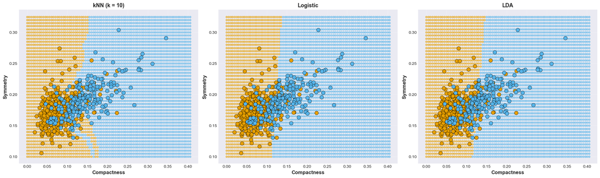

```python
# Choose best method: prediction on 2 features
from sklearn.linear_model import LogisticRegression
from sklearn.discriminant_analysis import LinearDiscriminantAnalysis
from sklearn.neighbors import KNeighborsClassifier

# Select two features
data_train = breast_cancer[['diagnosis', 'mean compactness', 'mean symmetry']].copy()
data_train = data_train.rename(columns={'diagnosis': 'class',
                                         'mean compactness': 'x1',
                                         'mean symmetry': 'x2'})

X_train = data_train[['x1', 'x2']].values
y_train = (data_train['class'] == 'malignant').astype(int).values  # Convert to 0/1

# Create prediction grid
h = 0.005
x1_arr = np.arange(0, 0.41, h)
x2_arr = np.arange(0.1, 0.33, h)
x1_grid, x2_grid = np.meshgrid(x1_arr, x2_arr)
X_grid = np.column_stack([x1_grid.ravel(), x2_grid.ravel()])

# Fit models
lda = LinearDiscriminantAnalysis()
lda.fit(X_train, y_train)

logistic = LogisticRegression(random_state=4,C=1000)
logistic.fit(X_train, y_train)

knn = KNeighborsClassifier(n_neighbors=10)
knn.fit(X_train, y_train)

# Predictions
y_pred_lda = lda.predict(X_grid)
y_pred_logistic = logistic.predict(X_grid)
y_pred_knn = knn.predict(X_grid)

data_pred = pd.DataFrame({
    'class': np.concatenate([y_pred_knn, y_pred_logistic, y_pred_lda]),
    'x1': np.tile(X_grid[:, 0], 3),
    'x2': np.tile(X_grid[:, 1], 3),
    'type': np.repeat(['kNN (k = 10)', 'Logistic', 'LDA'], len(X_grid))
})

# Plot
fig, axes = plt.subplots(1, 3, figsize=(20, 6))

for idx, (ax, method) in enumerate(zip(axes, ['kNN (k = 10)', 'Logistic', 'LDA'])):
    data_m = data_pred[data_pred['type'] == method]

    # Plot decision boundary
    for cls in [0, 1]:
        mask = data_m['class'] == cls
        ax.scatter(data_m[mask]['x1'], data_m[mask]['x2'],
                  s=20, color=cbPalette[cls+1], alpha=0.5)

    # Plot training data
    for cls in [0, 1]:
        mask = (data_train['class'] == 'benign') if cls == 0 else (data_train['class'] == 'malignant')
        ax.scatter(data_train[mask]['x1'], data_train[mask]['x2'],
                  s=80, color=cbPalette[cls+1], edgecolors='black', linewidth=0.5)

    ax.set_xlabel('Compactness', fontsize=12, fontweight='bold')
    ax.set_ylabel('Symmetry', fontsize=12, fontweight='bold')
    ax.set_title(method, fontsize=13, fontweight='bold')
    ax.grid(True, alpha=0.3)

plt.tight_layout()
plt.show()
```

When should you use which method?

This is the whole bias-variance trade-off question. Is the true decision boundary complex or simple? How much data do you have?

If you have a lot of data you can afford to model complex decision boundaries but if you have limited amounts of data it might be better to simplify the decision boundaries even if the ground truth is complex.

```python
# Cross-validation to compare methods
from sklearn.model_selection import StratifiedKFold
from sklearn.linear_model import LogisticRegression
from sklearn.discriminant_analysis import LinearDiscriminantAnalysis
from sklearn.neighbors import KNeighborsClassifier

# Use same training data
data_train = breast_cancer[['diagnosis', 'mean compactness', 'mean symmetry']].copy()
data_train = data_train.rename(columns={'diagnosis': 'class',
                                         'mean compactness': 'x1',
                                         'mean symmetry': 'x2'})

X_train = data_train[['x1', 'x2']].values
y_train = (data_train['class'] == 'malignant').astype(int).values

# 10-fold cross-validation
kf = StratifiedKFold(n_splits=10, shuffle=True, random_state=7374)

errors = {'knn': [], 'logistic': [], 'lda': []}

for train_idx, test_idx in kf.split(X_train, y_train):
    X_train_fold = X_train[train_idx]
    y_train_fold = y_train[train_idx]
    X_test_fold = X_train[test_idx]
    y_test_fold = y_train[test_idx]

    # Fit models
    lda = LinearDiscriminantAnalysis().fit(X_train_fold, y_train_fold)
    logistic = LogisticRegression(random_state=42,C=1000).fit(X_train_fold, y_train_fold)
    knn = KNeighborsClassifier(n_neighbors=10).fit(X_train_fold, y_train_fold)

    # Predict and calculate errors
    errors['knn'].append(np.mean(knn.predict(X_test_fold) != y_test_fold))
    errors['logistic'].append(np.mean(logistic.predict(X_test_fold) != y_test_fold))
    errors['lda'].append(np.mean(lda.predict(X_test_fold) != y_test_fold))

# Summary
cv_res = pd.DataFrame({
    'Method': ['kNN', 'Logistic', 'LDA'],
    'Mean Error': [np.mean(errors['knn']), np.mean(errors['logistic']), np.mean(errors['lda'])],
    'Std Error': [np.std(errors['knn']), np.std(errors['logistic']), np.std(errors['lda'])]
}).round(3)

print(cv_res)
```

```
     Method  Mean Error  Std Error
0       kNN       0.193      0.042
1  Logistic       0.200      0.047
2       LDA       0.220      0.050
```

```python
# Functions to demonstrate global vs local decision boundaries
def generate_data(boundary_func, seed=42):
    """Generate classification data with a given decision boundary"""
    np.random.seed(seed)

    # Generate boundary
    x2_boundary = np.arange(-6, 6.1, 0.1)
    x1_boundary = boundary_func(x2_boundary)

    # Simulate data points in [-2, 2] x [-6, 6] and classify
    X_all = np.random.rand(800, 2)
    X_all[:, 0] = 4 * (X_all[:, 0] - 0.5)
    X_all[:, 1] = 12 * (X_all[:, 1] - 0.5)

    # Classify based on boundary
    y_all = (X_all[:, 0] < boundary_func(X_all[:, 1])).astype(int)

    return {
        'X': X_all,
        'y': y_all,
        'boundary_x1': x1_boundary,
        'boundary_x2': x2_boundary
    }

# Simple boundary
def boundary_simple(x2):
    return -0.075 + 0.35 / 6 * x2

# Complex boundary
def boundary_complex(x2):
    return 3.5 / (x2 + 9) * np.sin((x2 + 9) / 0.7) + 0.1 * np.sin((x2 + 7) / 0.2)

data_simple = generate_data(boundary_simple)
data_complex = generate_data(boundary_complex)

print(f"Generated simple boundary data: {data_simple['X'].shape}")
print(f"Generated complex boundary data: {data_complex['X'].shape}")
```

```
Generated simple boundary data: (800, 2)
Generated complex boundary data: (800, 2)
```

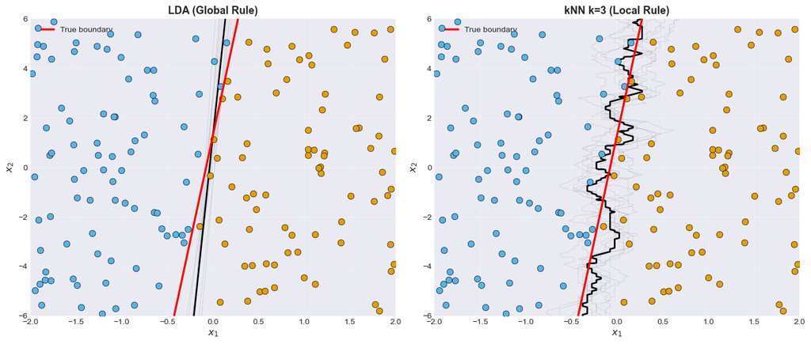

```python
# Visualize global vs local rules on simple boundary
from sklearn.discriminant_analysis import LinearDiscriminantAnalysis
from sklearn.neighbors import KNeighborsClassifier

# Simple boundary
data = data_simple

# Create grid for visualization
h = 0.05
x1s = np.arange(-2, 2.05, h)
x2s = np.arange(-6, 6.05, h)
x1_grid, x2_grid = np.meshgrid(x1s, x2s)
X_grid = np.column_stack([x1_grid.ravel(), x2_grid.ravel()])

# Store predictions from multiple samples
M = 10  # Number of samples
lda_models = []
knn_models = []
y_pred_lda_all = []
y_pred_knn_all = []

# Generate 10 different samples (20% of data each) and fit models
for m in range(M):
    np.random.seed(2636472 + m)
    sample_idx = np.random.choice(len(data['X']), size=int(0.2 * len(data['X'])), replace=False)
    X_train_sample = data['X'][sample_idx]
    y_train_sample = data['y'][sample_idx]

    # Fit models
    lda = LinearDiscriminantAnalysis().fit(X_train_sample, y_train_sample)
    knn = KNeighborsClassifier(n_neighbors=3).fit(X_train_sample, y_train_sample)

    # Store fitted models
    lda_models.append(lda)
    knn_models.append(knn)

    # Store predictions
    y_pred_lda_all.append(lda.predict(X_grid))
    y_pred_knn_all.append(knn.predict(X_grid))

# Create subplots
fig, axes = plt.subplots(1, 2, figsize=(14, 6))

# ===== LDA Panel (Left) =====
ax = axes[0]

# Plot individual LDA decision boundaries (light grey)
for lda in lda_models:
    # Get decision function (log-odds) for linear boundary
    decision = lda.decision_function(X_grid).reshape(x1_grid.shape)
    ax.contour(x1_grid, x2_grid, decision, levels=[0], colors='grey', linewidths=0.5, alpha=0.3)

# Plot average LDA boundary (black) - average decision functions
decision_functions = np.array([lda.decision_function(X_grid) for lda in lda_models])
decision_avg = np.mean(decision_functions, axis=0).reshape(x1_grid.shape)
ax.contour(x1_grid, x2_grid, decision_avg, levels=[0], colors='black', linewidths=2)

# Plot true boundary in red
ax.plot(data['boundary_x1'], data['boundary_x2'],
       color='red', linewidth=2.5, label='True boundary', zorder=100)

# Get one sample for training data visualization
np.random.seed(2636472)
sample_idx = np.random.choice(len(data['X']), size=int(0.2 * len(data['X'])), replace=False)
X_sample = data['X'][sample_idx]
y_sample = data['y'][sample_idx]

# Plot training data
for cls in [0, 1]:
    mask = y_sample == cls
    ax.scatter(X_sample[mask, 0], X_sample[mask, 1],
              s=60, color=cbPalette[cls+1], edgecolors='black', linewidth=0.5, zorder=50)

ax.set_xlabel(r'$x_1$', fontsize=12, fontweight='bold')
ax.set_ylabel(r'$x_2$', fontsize=12, fontweight='bold')
ax.set_title('LDA (Global Rule)', fontsize=13, fontweight='bold')
ax.set_xlim(-2, 2)
ax.set_ylim(-6, 6)
ax.grid(True, alpha=0.3)
ax.legend(fontsize=10)

# ===== kNN Panel (Right) =====
ax = axes[1]

# Plot individual kNN decision boundaries (light grey)
for m in range(M):
    y_pred_reshaped = y_pred_knn_all[m].reshape(x1_grid.shape)
    ax.contour(x1_grid, x2_grid, y_pred_reshaped, levels=[0.5], colors='grey', linewidths=0.5, alpha=0.3)

# Plot average kNN boundary (black)
y_pred_knn_avg = np.round(np.mean(np.array(y_pred_knn_all), axis=0)).astype(int)
y_pred_knn_avg_reshaped = y_pred_knn_avg.reshape(x1_grid.shape)
ax.contour(x1_grid, x2_grid, y_pred_knn_avg_reshaped, levels=[0.5], colors='black', linewidths=2)

# Plot true boundary in red
ax.plot(data['boundary_x1'], data['boundary_x2'],
       color='red', linewidth=2.5, label='True boundary', zorder=100)

# Plot training data
for cls in [0, 1]:
    mask = y_sample == cls
    ax.scatter(X_sample[mask, 0], X_sample[mask, 1],
              s=60, color=cbPalette[cls+1], edgecolors='black', linewidth=0.5, zorder=50)

ax.set_xlabel(r'$x_1$', fontsize=12, fontweight='bold')
ax.set_ylabel(r'$x_2$', fontsize=12, fontweight='bold')
ax.set_title('kNN k=3 (Local Rule)', fontsize=13, fontweight='bold')
ax.set_xlim(-2, 2)
ax.set_ylim(-6, 6)
ax.grid(True, alpha=0.3)
ax.legend(fontsize=10)

plt.tight_layout()
plt.show()
```

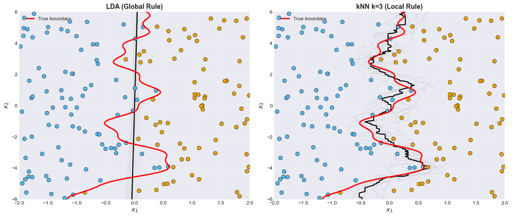

```python
# Visualize global vs local rules on complex boundary
data = data_complex

# Create grid for visualization
h = 0.05
x1s = np.arange(-2, 2.05, h)
x2s = np.arange(-6, 6.05, h)
x1_grid, x2_grid = np.meshgrid(x1s, x2s)
X_grid = np.column_stack([x1_grid.ravel(), x2_grid.ravel()])

# Store predictions from multiple samples
M = 10  # Number of samples
lda_models = []
knn_models = []
y_pred_lda_all = []
y_pred_knn_all = []

# Generate 10 different samples (20% of data each) and fit models
for m in range(M):
    np.random.seed(2636472 + m)
    sample_idx = np.random.choice(len(data['X']), size=int(0.2 * len(data['X'])), replace=False)
    X_train_sample = data['X'][sample_idx]
    y_train_sample = data['y'][sample_idx]

    # Fit models
    lda = LinearDiscriminantAnalysis().fit(X_train_sample, y_train_sample)
    knn = KNeighborsClassifier(n_neighbors=3).fit(X_train_sample, y_train_sample)

    # Store fitted models
    lda_models.append(lda)
    knn_models.append(knn)

    # Store predictions
    y_pred_lda_all.append(lda.predict(X_grid))
    y_pred_knn_all.append(knn.predict(X_grid))

# Create subplots
fig, axes = plt.subplots(1, 2, figsize=(14, 6))

# ===== LDA Panel (Left) =====
ax = axes[0]

# Plot individual LDA decision boundaries (light grey)
for lda in lda_models:
    # Get decision function (log-odds) for linear boundary
    decision = lda.decision_function(X_grid).reshape(x1_grid.shape)
    ax.contour(x1_grid, x2_grid, decision, levels=[0], colors='grey', linewidths=0.5, alpha=0.3)

# Plot average LDA boundary (black) - average decision functions
decision_functions = np.array([lda.decision_function(X_grid) for lda in lda_models])
decision_avg = np.mean(decision_functions, axis=0).reshape(x1_grid.shape)
ax.contour(x1_grid, x2_grid, decision_avg, levels=[0], colors='black', linewidths=2)

# Plot true boundary in red
ax.plot(data['boundary_x1'], data['boundary_x2'],
       color='red', linewidth=2.5, label='True boundary', zorder=100)

# Get one sample for training data visualization
np.random.seed(2636472)
sample_idx = np.random.choice(len(data['X']), size=int(0.2 * len(data['X'])), replace=False)
X_sample = data['X'][sample_idx]
y_sample = data['y'][sample_idx]

# Plot training data
for cls in [0, 1]:
    mask = y_sample == cls
    ax.scatter(X_sample[mask, 0], X_sample[mask, 1],
              s=60, color=cbPalette[cls+1], edgecolors='black', linewidth=0.5, zorder=50)

ax.set_xlabel(r'$x_1$', fontsize=12, fontweight='bold')
ax.set_ylabel(r'$x_2$', fontsize=12, fontweight='bold')
ax.set_title('LDA (Global Rule)', fontsize=13, fontweight='bold')
ax.set_xlim(-2, 2)
ax.set_ylim(-6, 6)
ax.grid(True, alpha=0.3)
ax.legend(fontsize=10)

# ===== kNN Panel (Right) =====
ax = axes[1]

# Plot individual kNN decision boundaries (light grey)
for m in range(M):
    y_pred_reshaped = y_pred_knn_all[m].reshape(x1_grid.shape)
    ax.contour(x1_grid, x2_grid, y_pred_reshaped, levels=[0.5], colors='grey', linewidths=0.5, alpha=0.3)

# Plot average kNN boundary (black)
y_pred_knn_avg = np.round(np.mean(np.array(y_pred_knn_all), axis=0)).astype(int)
y_pred_knn_avg_reshaped = y_pred_knn_avg.reshape(x1_grid.shape)
ax.contour(x1_grid, x2_grid, y_pred_knn_avg_reshaped, levels=[0.5], colors='black', linewidths=2)

# Plot true boundary in red
ax.plot(data['boundary_x1'], data['boundary_x2'],
       color='red', linewidth=2.5, label='True boundary', zorder=100)

# Plot training data
for cls in [0, 1]:
    mask = y_sample == cls
    ax.scatter(X_sample[mask, 0], X_sample[mask, 1],
              s=60, color=cbPalette[cls+1], edgecolors='black', linewidth=0.5, zorder=50)

ax.set_xlabel(r'$x_1$', fontsize=12, fontweight='bold')
ax.set_ylabel(r'$x_2$', fontsize=12, fontweight='bold')
ax.set_title('kNN k=3 (Local Rule)', fontsize=13, fontweight='bold')
ax.set_xlim(-2, 2)
ax.set_ylim(-6, 6)
ax.grid(True, alpha=0.3)
ax.legend(fontsize=10)

plt.tight_layout()
plt.show()
```

In the above examples you can see how a rigid and flexible model behaves when the ground truth is simple or complex respectively.

Here is a numerical summary of the relative performance of the methods.

```python
# Numerical comparison: Local vs Global performance
from sklearn.model_selection import StratifiedKFold
from sklearn.discriminant_analysis import LinearDiscriminantAnalysis
from sklearn.neighbors import KNeighborsClassifier

data_list = [data_simple, data_complex]
boundary_names = ['Simple', 'Complex']

# 10-fold cross-validation
kf = StratifiedKFold(n_splits=10, shuffle=True, random_state=2636472)

results = {'Simple': {}, 'Complex': {}}

for data, name in zip(data_list, boundary_names):
    errors_lda = []
    errors_knn = []

    for train_idx, test_idx in kf.split(data['X'], data['y']):
        X_train = data['X'][train_idx]
        y_train = data['y'][train_idx]
        X_test = data['X'][test_idx]
        y_test = data['y'][test_idx]

        # Fit models
        lda = LinearDiscriminantAnalysis().fit(X_train, y_train)
        knn = KNeighborsClassifier(n_neighbors=3).fit(X_train, y_train)

        # Test errors
        errors_lda.append(np.mean(lda.predict(X_test) != y_test))
        errors_knn.append(np.mean(knn.predict(X_test) != y_test))

    results[name]['lda'] = (np.mean(errors_lda), np.std(errors_lda))
    results[name]['knn'] = (np.mean(errors_knn), np.std(errors_knn))

# Display results
print("Cross-validation Error Rates:")
print("\nSimple Boundary:")
print(f"  LDA:  {results['Simple']['lda'][0]:.3f} ± {results['Simple']['lda'][1]:.3f}")
print(f"  kNN:  {results['Simple']['knn'][0]:.3f} ± {results['Simple']['knn'][1]:.3f}")
print("\nComplex Boundary:")
print(f"  LDA:  {results['Complex']['lda'][0]:.3f} ± {results['Complex']['lda'][1]:.3f}")
print(f"  kNN:  {results['Complex']['knn'][0]:.3f} ± {results['Complex']['knn'][1]:.3f}")
```

```
Cross-validation Error Rates:

Simple Boundary:
  LDA:  0.019 ± 0.014
  kNN:  0.020 ± 0.014

Complex Boundary:
  LDA:  0.057 ± 0.020
  kNN:  0.031 ± 0.013
```

Let's try this on the breast cancer data.

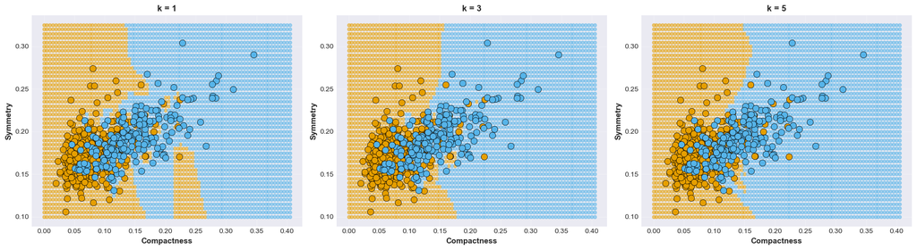

```python
# Choose k in kNN
from sklearn.neighbors import KNeighborsClassifier

# Use breast cancer data
data_train = breast_cancer[['diagnosis', 'mean compactness', 'mean symmetry']].copy()
data_train = data_train.rename(columns={'diagnosis': 'class',
                                         'mean compactness': 'x1',
                                         'mean symmetry': 'x2'})

X_train = data_train[['x1', 'x2']].values
y_train = (data_train['class'] == 'malignant').astype(int).values

# Create prediction grid
h = 0.005
x1_arr = np.arange(0, 0.41, h)
x2_arr = np.arange(0.1, 0.33, h)
x1_grid, x2_grid = np.meshgrid(x1_arr, x2_arr)
X_grid = np.column_stack([x1_grid.ravel(), x2_grid.ravel()])

ks = [1, 3, 5]
predictions = []

for k in ks:
    clf = KNeighborsClassifier(n_neighbors=k)
    clf.fit(X_train, y_train)
    y_pred = clf.predict(X_grid)
    predictions.append(y_pred)

# Prepare data for plotting
data_pred = pd.DataFrame({
    'class': np.concatenate(predictions),
    'x1': np.tile(X_grid[:, 0], len(ks)),
    'x2': np.tile(X_grid[:, 1], len(ks)),
    'k': np.repeat([f'k = {k}' for k in ks], len(X_grid))
})

# Plot
fig, axes = plt.subplots(1, 3, figsize=(18, 5))

for idx, (ax, k) in enumerate(zip(axes, ks)):
    data_k = data_pred[data_pred['k'] == f'k = {k}']

    # Plot decision boundary
    for cls in [0, 1]:
        mask = data_k['class'] == cls
        ax.scatter(data_k[mask]['x1'], data_k[mask]['x2'],
                  s=20, color=cbPalette[cls+1], alpha=0.5)

    # Plot training data
    for cls in [0, 1]:
        mask = (data_train['class'] == 'benign') if cls == 0 else (data_train['class'] == 'malignant')
        ax.scatter(data_train[mask]['x1'], data_train[mask]['x2'],
                  s=80, color=cbPalette[cls+1], edgecolors='black', linewidth=0.5)

    ax.set_xlabel('Compactness', fontsize=11, fontweight='bold')
    ax.set_ylabel('Symmetry', fontsize=11, fontweight='bold')
    ax.set_title(f'k = {k}', fontsize=12, fontweight='bold')
    ax.grid(True, alpha=0.3)

plt.tight_layout()
plt.show()
```

You can see how the decision boundary goes from flexible to more rigid. Try different k at home.

How do we find the best k?

Cross-validation. Split the data repeatedly and see which k works best for predicting the left out parts of the data.

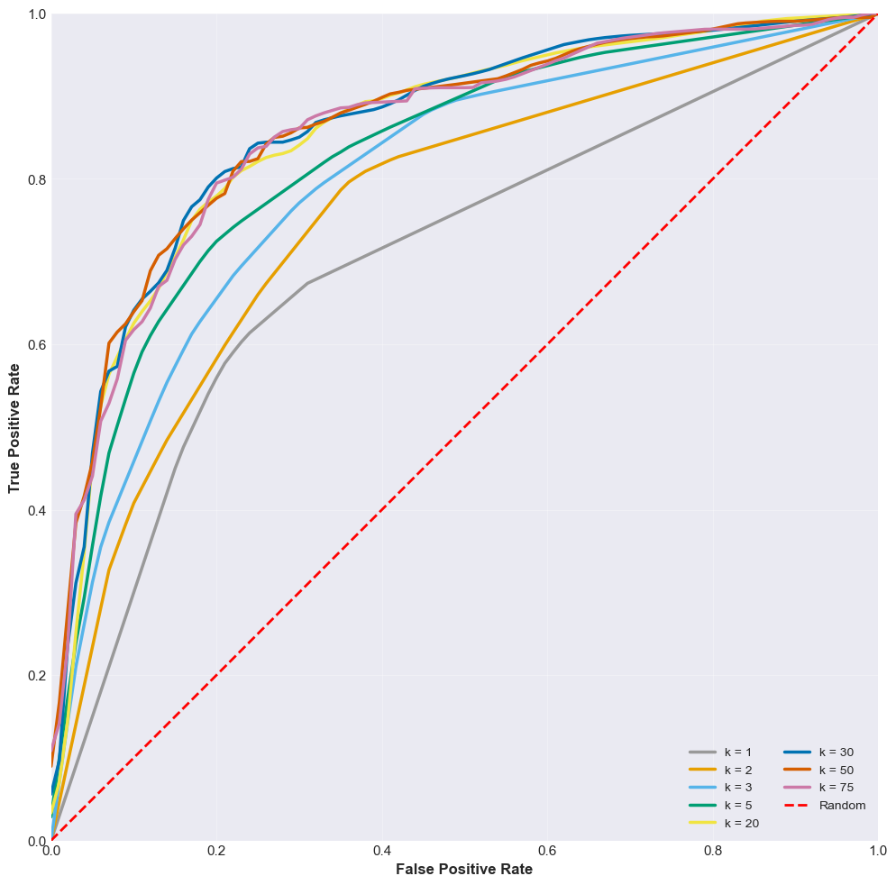

```
Cross-validation Error Rates:

Test Errors:
k =  1: 0.276 ± 0.038
k =  2: 0.271 ± 0.026
k =  3: 0.242 ± 0.027
k =  5: 0.227 ± 0.018
k = 20: 0.202 ± 0.024
k = 30: 0.202 ± 0.019
k = 50: 0.207 ± 0.021
k = 75: 0.211 ± 0.018

Train Errors:
k =  1: 0.000 ± 0.000
k =  2: 0.144 ± 0.013
k =  3: 0.135 ± 0.011
k =  5: 0.163 ± 0.009
k = 20: 0.183 ± 0.011
k = 30: 0.191 ± 0.012
k = 50: 0.194 ± 0.013
k = 75: 0.205 ± 0.006
```

```python
# Choose best k in kNN using ROC curves
from sklearn.neighbors import KNeighborsClassifier
from sklearn.model_selection import StratifiedKFold
from sklearn.metrics import roc_curve, auc

# Use breast cancer data
data_train = breast_cancer[['diagnosis', 'mean compactness', 'mean symmetry']].copy()
data_train = data_train.rename(columns={'diagnosis': 'class',
                                         'mean compactness': 'x1',
                                         'mean symmetry': 'x2'})

X_train = data_train[['x1', 'x2']].values
y_train = (data_train['class'] == 'malignant').astype(int).values

ks = [1, 2, 3, 5, 20, 30, 50, 75]
fpr_grid = np.arange(0, 1.01, 0.01)

# 5-fold cross-validation
kf = StratifiedKFold(n_splits=5, shuffle=True, random_state=7374)

roc_data_all = []
cv_errors = {k: {'test': [], 'train': []} for k in ks}

for k in ks:
    tpr_all_folds = []

    for train_idx, test_idx in kf.split(X_train, y_train):
        X_train_fold = X_train[train_idx]
        y_train_fold = y_train[train_idx]
        X_test_fold = X_train[test_idx]
        y_test_fold = y_train[test_idx]

        # Fit kNN
        clf = KNeighborsClassifier(n_neighbors=k)
        clf.fit(X_train_fold, y_train_fold)

        # Get probabilities
        y_proba = clf.predict_proba(X_test_fold)[:, 1]
        y_proba_train = clf.predict_proba(X_train_fold)[:, 1]

        # Calculate ROC
        fpr, tpr, _ = roc_curve(y_test_fold, y_proba)
        tpr_interp = np.interp(fpr_grid, fpr, tpr)
        tpr_all_folds.append(tpr_interp)

        # Calculate errors
        y_pred_test = clf.predict(X_test_fold)
        y_pred_train = clf.predict(X_train_fold)
        cv_errors[k]['test'].append(np.mean(y_pred_test != y_test_fold))
        cv_errors[k]['train'].append(np.mean(y_pred_train != y_train_fold))

    # Average TPR across folds
    tpr_mean = np.mean(tpr_all_folds, axis=0)
    for fpr, tpr in zip(fpr_grid, tpr_mean):
        roc_data_all.append({'k': k, 'fpr': fpr, 'tpr': tpr})

roc_df = pd.DataFrame(roc_data_all)

# Plot ROC curves
plt.figure(figsize=(10, 10))
for k in ks:
    data_k = roc_df[roc_df['k'] == k]
    plt.plot(data_k['fpr'], data_k['tpr'], linewidth=2.5, label=f'k = {k}')

# Diagonal line (random classifier)
plt.plot([0, 1], [0, 1], 'r--', linewidth=2, label='Random')

plt.xlabel('False Positive Rate', fontsize=12, fontweight='bold')
plt.ylabel('True Positive Rate', fontsize=12, fontweight='bold')
plt.xlim(0, 1)
plt.ylim(0, 1)
plt.xticks(fontsize=11)
plt.yticks(fontsize=11)
plt.legend(fontsize=10, loc='lower right', ncol=2)
plt.gca().set_aspect('equal')
plt.grid(True, alpha=0.3)
plt.tight_layout()
plt.show()

# Print error rates
print("\nCross-validation Error Rates:")
print("\nTest Errors:")
for k in ks:
    mean_err = np.mean(cv_errors[k]['test'])
    std_err = np.std(cv_errors[k]['test'])
    print(f"k = {k:2d}: {mean_err:.3f} ± {std_err:.3f}")

print("\nTrain Errors:")
for k in ks:
    mean_err = np.mean(cv_errors[k]['train'])
    std_err = np.std(cv_errors[k]['train'])
    print(f"k = {k:2d}: {mean_err:.3f} ± {std_err:.3f}")
```